# Exercise 06

Author

Hubert Rehrauer

Published

October 23, 2023

```r
library(ggplot2)
library(pheatmap)
library(dplyr)
```

## Comparison of Expression Estimates

The data set consists for 3 Normal samples and 3 Treated samples with 2.5 Mio reads each. The reads are simulated to come from genes on the human chromosome 1.

The expression values from featureCounts were created with: We use the library `Rsubread` to generate the counts

```r
library(Rsubread)
# fill in path of SAM / BAM file for ... (countResult files already provided to us --> not required here)
countResult1 = featureCounts(..., strandSpecific=0,
                                 GTF.featureType="exon", GTF.attrType="gene_id", useMetaFeatures=TRUE,
                                 allowMultiOverlap=TRUE, countMultiMappingReads=FALSE)
save(countResult1, file="countResult1.RData")
countResult2 = featureCounts(..., strandSpecific=0,
                                 GTF.featureType="exon", GTF.attrType="gene_id", useMetaFeatures=TRUE,
                                 allowMultiOverlap=TRUE, countMultiMappingReads=TRUE, fraction=TRUE)
save(countResult2, file="countResult2.RData")
```

The RSEM data were generated with

```bash
# is a software package designed to estimate gene and isoform expression levels from RNA-Seq data
rsem-calculate-expression .... --calc-pme --calc-ci --strandedness none ...
```

For documentation see: http://deweylab.github.io/RSEM/rsem-calculate-expression.html

## Exercises

1. Depending on the featureCount mode, how many alignments are ignored during counting?
2. Compare the counts from featureCounts with the genelevel counts from RSEM. Which genes have different values?
3. How does the sum of the counts in RSEM compare to the number of the aligned reads?
4. Compute pair-wise correlation of the samples based on the isoform counts and gene level counts

```r
# load data (featureCounts)
countResult1 <- readRDS("countResult1.RDS")
countResult2 <- readRDS("countResult2.RDS")
```

```r
# load data (RSEM, gene level)
RSEM_N1_genes <- read.table("RSEM_counts/N1.genes.results", header=TRUE, sep="\t")
RSEM_N2_genes <- read.table("RSEM_counts/N2.genes.results", header=TRUE, sep="\t")
RSEM_N3_genes <- read.table("RSEM_counts/N3.genes.results", header=TRUE, sep="\t")

RSEM_T1_genes <- read.table("RSEM_counts/T1.genes.results", header=TRUE, sep="\t")
RSEM_T2_genes <- read.table("RSEM_counts/T2.genes.results", header=TRUE, sep="\t")
RSEM_T3_genes <- read.table("RSEM_counts/T3.genes.results", header=TRUE, sep="\t")

RSEM_genes_list = list(RSEM_N1_genes, RSEM_N2_genes, RSEM_N3_genes, RSEM_T1_genes, RSEM_T2_genes, RSEM_T3_genes)
```

```r
# load data (RSEM, isoform level)
RSEM_N1_isoforms <- read.table("RSEM_counts/N1.isoforms.results", header=TRUE, sep="\t")
RSEM_N2_isoforms <- read.table("RSEM_counts/N2.isoforms.results", header=TRUE, sep="\t")
RSEM_N3_isoforms <- read.table("RSEM_counts/N3.isoforms.results", header=TRUE, sep="\t")

RSEM_T1_isoforms <- read.table("RSEM_counts/T1.isoforms.results", header=TRUE, sep="\t")
RSEM_T2_isoforms <- read.table("RSEM_counts/T2.isoforms.results", header=TRUE, sep="\t")
RSEM_T3_isoforms <- read.table("RSEM_counts/T3.isoforms.results", header=TRUE, sep="\t")

RSEM_isoforms_list = list(RSEM_N1_isoforms, RSEM_N2_isoforms, RSEM_N3_isoforms, RSEM_T1_isoforms, RSEM_T2_isoforms, RSEM_T3_isoforms)
```

## Question 1

*Depending on the featureCount mode, how many alignments are ignored during counting?*

```r
# count result 1
print(countResult1$stat)
```

```
                      Status STAR_mapped.N1.bam STAR_mapped.N2.bam
1                   Assigned            2476971            2475323
2       Unassigned_Ambiguity                  0                  0
3    Unassigned_MultiMapping              50267              54371
4      Unassigned_NoFeatures                133                135
5        Unassigned_Unmapped                  0                  0
6  Unassigned_MappingQuality                  0                  0
7  Unassigned_FragmentLength                  0                  0
8         Unassigned_Chimera                  0                  0
9       Unassigned_Secondary                  0                  0
10    Unassigned_Nonjunction                  0                  0
11      Unassigned_Duplicate                  0                  0
   STAR_mapped.N3.bam STAR_mapped.T1.bam STAR_mapped.T2.bam STAR_mapped.T3.bam
1             2474827            2455326            2463833            2463489
2                   0                  0                  0                  0
3               56208              97028              80619              80559
4                 115                142                120                133
5                   0                  0                  0                  0
6                   0                  0                  0                  0
7                   0                  0                  0                  0
8                   0                  0                  0                  0
9                   0                  0                  0                  0
10                  0                  0                  0                  0
11                  0                  0                  0                  0
```

```r
summed_alignment_stats = rowSums(countResult1$stat[, 2:ncol(countResult1$stat)])
paste("Assigned reads: ", summed_alignment_stats[1])
```

```
[1] "Assigned reads:  14809769"
```

```r
paste("Unassigned reads due to multimapping: ", summed_alignment_stats[3])
```

```
[1] "Unassigned reads due to multimapping:  419052"
```

```r
paste("Unassigned reads due to no features: ", summed_alignment_stats[4])
```

```
[1] "Unassigned reads due to no features:  778"
```

419 052 reads are ignored during alignment because they map to multiple genes from CountResults1 and 778 reads were not assigned to any feature.

```r
# count result 2
print(countResult2$stat)
```

```
                      Status STAR_mapped.N1.bam STAR_mapped.N2.bam
1                   Assigned            2524127            2526106
2       Unassigned_Ambiguity                  0                  0
3    Unassigned_MultiMapping                  0                  0
4      Unassigned_NoFeatures               3244               3723
5        Unassigned_Unmapped                  0                  0
6  Unassigned_MappingQuality                  0                  0
7  Unassigned_FragmentLength                  0                  0
8         Unassigned_Chimera                  0                  0
9       Unassigned_Secondary                  0                  0
10    Unassigned_Nonjunction                  0                  0
11      Unassigned_Duplicate                  0                  0
   STAR_mapped.N3.bam STAR_mapped.T1.bam STAR_mapped.T2.bam STAR_mapped.T3.bam
1             2527485            2541426            2537585            2537351
2                   0                  0                  0                  0
3                   0                  0                  0                  0
4                3665              11070               6987               6830
5                   0                  0                  0                  0
6                   0                  0                  0                  0
7                   0                  0                  0                  0
8                   0                  0                  0                  0
9                   0                  0                  0                  0
10                  0                  0                  0                  0
11                  0                  0                  0                  0
```

```r
summed_alignment_stats = rowSums(countResult2$stat[, 2:ncol(countResult2$stat)])
paste("Assigned reads: ", summed_alignment_stats[1])
```

```
[1] "Assigned reads:  15194080"
```

```r
paste("Unassigned reads due to multimapping: ", summed_alignment_stats[3])
```

```
[1] "Unassigned reads due to multimapping:  0"
```

```r
paste("Unassigned reads due to no features: ", summed_alignment_stats[4])
```

```
[1] "Unassigned reads due to no features:  35519"
```

No reads are ignored during alignment because they map to multiple genes from CountResults2 but 35 519 reads were not assigned to any feature. Thats because countResults2 allows multimapping reads, the algorithm assigns fractional counts.

## Question 2

*Compare the counts from featureCounts with the genelevel counts from RSEM. Which genes have different values?*

```r
# get raw count matrices
fc_counts = countResult1$counts
fc_counts_mm = countResult2$counts

expected_counts_list <- lapply(RSEM_genes_list, function(count_df) {
  return(count_df$expected_count)
})
RSEM_counts <- do.call(cbind, expected_counts_list)
colnames(RSEM_counts) <- c("N1", "N2", "N3", "T1", "T2", "T3")
rownames(RSEM_counts) = RSEM_T3_genes$gene_id

# order dataframes in the same way
RSEM_counts = RSEM_counts[rownames(fc_counts), ]

# percentage of genes with same counts (all samples are included in comparison)
sum(fc_counts == RSEM_counts) / (dim(RSEM_counts)[1]*dim(RSEM_counts)[2])
```

```
[1] 0.5898687
```

```r
# look at distribution of equal and unequal counts
equal_counts = table(fc_counts[fc_counts == RSEM_counts])
unequal_counts = table(fc_counts[fc_counts != RSEM_counts])
print(equal_counts[1:100])
```

```
    0     1     2     3     4     5     6     7     8     9    10    11    12
15420   605   428   275   194   169   112   108    99    69    60    60    58
   13    14    15    16    17    18    19    20    21    22    23    24    25
   32    49    41    26    31    29    27    23    21    22    15    11    19
   26    27    28    29    30    31    32    33    34    35    36    37    38
   19    16    15    17    10     9     6    13    13    16    11    12    10
   39    40    41    42    43    44    45    46    47    48    49    50    51
   11    10    10     8     3     7     5     3     4    11     6     3     5
   52    53    54    55    56    57    58    59    60    61    62    63    64
    6     5     6     7     5     5     2    11     2     7     1     2     1
   65    66    67    68    69    70    71    72    73    74    75    76    77
    4     5     3     1     3     1     1     2     2     1     4     3     3
   78    79    80    81    82    83    84    85    86    87    88    89    90
    3     2     2     2     3     3     3     3     1     5     3     1     3
   91    92    93    94    95    96    98    99   101
    2     5     1     1     1     1     2     1     4
```

```r
print(unequal_counts[1:100])
```

```
  0   1   2   3   4   5   6   7   8   9  10  11  12  13  14  15  16  17  18  19
154 243 183 163 119 109 105 106  90  64  93  73  85  77  47  55  63  62  56  64
 20  21  22  23  24  25  26  27  28  29  30  31  32  33  34  35  36  37  38  39
 44  47  45  52  53  43  45  50  43  50  44  44  37  36  35  47  35  35  35  32
 40  41  42  43  44  45  46  47  48  49  50  51  52  53  54  55  56  57  58  59
 28  29  35  24  22  29  35  29  26  39  26  31  24  20  26  23  22  22  28  25
 60  61  62  63  64  65  66  67  68  69  70  71  72  73  74  75  76  77  78  79
 25  27  21  25  30  23  22  25  25  24  13  18  25  22  19  22  26  19  12  12
 80  81  82  83  84  85  86  87  88  89  90  91  92  93  94  95  96  97  98  99
 22  24  21  21  16  12  17  24  10  17  18  17  13  17  15  20  22  20  23  18
```

The percentage of genes with the same count comparing RSEM and feature counts without multimapping is 60%.

Looking at the distribution of the equal and unequal counts derived with the table function shows that genes with 0 counts or really low expression usually have the same counts in both methods. Genes with high expression have expression values in a similar range but not the same values. This can also be seen in the following barplots.

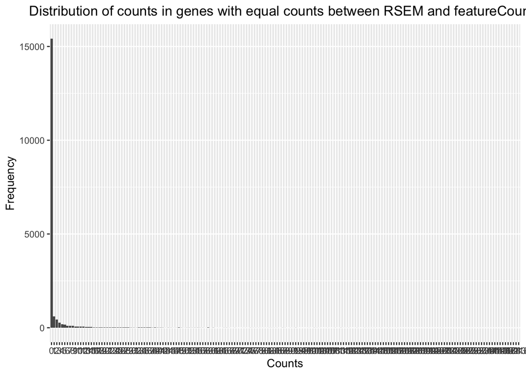

```r
barp_equal_counts = ggplot(data.frame(equal_counts), aes(x = Var1, y = Freq)) +
  geom_bar(stat = 'identity') +
  labs(title = "Distribution of counts in genes with equal counts between RSEM and featureCounts", x = "Counts", y = "Frequency") +
  theme(plot.title = element_text(hjust = 0.5))
print(barp_equal_counts)
```

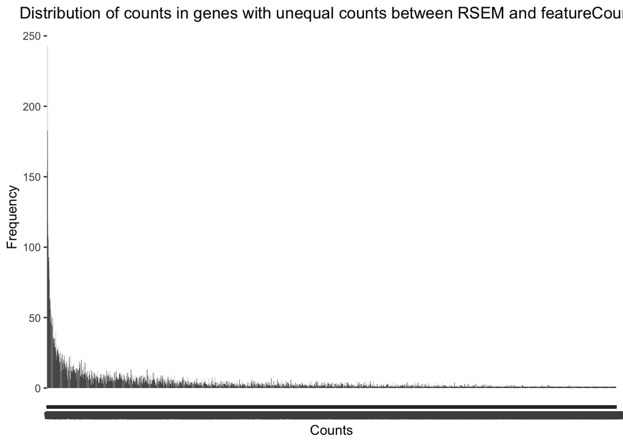

```r
barp_unequal_counts = ggplot(data.frame(unequal_counts), aes(x = Var1, y = Freq)) +
  geom_bar(stat = 'identity') +
  labs(title = "Distribution of counts in genes with unequal counts between RSEM and featureCounts", x = "Counts", y = "Frequency") +
  theme(plot.title = element_text(hjust = 0.5))
print(barp_unequal_counts)
```

```r
# compare multimapped counts of feature counts and RSEM
# percentage of genes with same counts (all samples are included in comparison)
sum(fc_counts_mm == RSEM_counts) / (dim(RSEM_counts)[1]*dim(RSEM_counts)[2])
```

```
[1] 0.5629941
```

```r
# look at distribution of equal and unequal counts
table(fc_counts_mm[fc_counts_mm == RSEM_counts])[1:100]
```

```
    0   0.5     1     2     3     4     5     6     7     8     9    10    11
14840     4   568   403   257   182   156   104    97    92    61    56    52
   12    13  13.5    14    15    16    17    18    19    20    21    22    23
   60    33     1    48    35    24    33    26    27    20    19    18    10
   24    25    26    27    28    29    30    31    32    33    34    35    36
   12    19    16    14    11    15     7    10    10    12    13    15     9
   37    38    39    40    41    42    43    44    45    46    47    48    49
   10    10     9     8     8     8     2     8     2     2     3    10     5
   50    51    52    53    54    55    56    57    58    59    60    61    63
    3     6     4     4     6     4     4     5     1     8     2     5     3
   64    65    66    67    69    70    71    72    73    74    75    76    77
    1     4     5     3     4     1     1     3     2     1     3     2     2
   78    80    81    82    83    84    85    86    87    88    89    90    91
    1     1     1     2     2     2     3     1     3     3     1     2     1
   92    94    96    98   101   102   103   105   106
    5     1     1     1     5     2     1     1     2
```

```r
table(fc_counts_mm[fc_counts_mm != RSEM_counts])[1:100]
```

```
0.11 0.14 0.17  0.2 0.25 0.31 0.33  0.4 0.48  0.5 0.57  0.6 0.64 0.67 0.73 0.75
   3    6   16   22   21    1   51    2    1  257    2    2    1   14    1    7
0.81 0.83 0.89 0.92 0.98    1 1.08 1.11 1.12 1.14 1.17  1.2 1.25 1.27 1.33 1.48
   1    4    1    1    2  184    1    1    1    4    2    3    8    1   15    2
 1.5  1.6 1.62 1.64 1.67 1.75 1.83 1.87 1.93 1.95    2 2.17  2.2 2.23 2.25 2.29
  54    1    1    1    9    2    7    1    1    2  137    6    3    2    4    1
2.33 2.34 2.38 2.42 2.43  2.5 2.57 2.64 2.67  2.7 2.83 2.95    3  3.1 3.14 3.17
   8    1    1    1    1   37    1    1    3    2    2    1  117    1    1    7
3.25 3.32 3.33  3.4 3.44 3.45  3.5 3.57 3.64 3.67 3.75 3.83 3.92    4 4.03 4.17
   4    1    6    1    1    1   21    1    3    2    2    6    1   87    1    2
 4.2 4.25 4.33 4.37 4.42 4.44 4.49  4.5 4.57 4.58 4.67 4.75 4.83  4.9 4.92 4.99
   2    1    3    1    2    1    1   29    1    1    4    1    4    1    1    1
   5 5.12 5.17  5.2
  64    2    3    1
```

A similar results is obtained comparing the multimapped counts. Here the percentage of genes with same counts is 56,3 %.

## Question 3

*How does the sum of the counts in RSEM compare to the number of the aligned reads?*

```r
# using total number of aligned reads from featureCounts (same for multimapped and not multimapped)
tot_reads = colSums(countResult1$stat[, 2:ncol(countResult2$stat)])
tot_reads
```

```
STAR_mapped.N1.bam STAR_mapped.N2.bam STAR_mapped.N3.bam STAR_mapped.T1.bam
           2527371            2529829            2531150            2552496
STAR_mapped.T2.bam STAR_mapped.T3.bam
           2544572            2544181
```

```r
# aligned reads with featureCounts
aligned_reads_fc = countResult1$stat[1, 2:ncol(countResult2$stat)]
aligned_reads_fc
```

```
  STAR_mapped.N1.bam STAR_mapped.N2.bam STAR_mapped.N3.bam STAR_mapped.T1.bam
1            2476971            2475323            2474827            2455326
  STAR_mapped.T2.bam STAR_mapped.T3.bam
1            2463833            2463489
```

```r
# aligned reads with featureCounts (multimapping)
aligned_reads_fc_mm = countResult2$stat[1, 2:ncol(countResult2$stat)]
aligned_reads_fc_mm
```

```
  STAR_mapped.N1.bam STAR_mapped.N2.bam STAR_mapped.N3.bam STAR_mapped.T1.bam
1            2524127            2526106            2527485            2541426
  STAR_mapped.T2.bam STAR_mapped.T3.bam
1            2537585            2537351
```

```r
# sum of counts in RSEM
aligned_reads_RSEM = colSums(RSEM_counts)
aligned_reads_RSEM
```

```
     N1      N2      N3      T1      T2      T3
2410621 2411935 2411696 2412459 2410414 2412864
```

Comparing sum of counts in RSEM with total number of reads to align per sample

```r
tot_reads - aligned_reads_RSEM
```

```
STAR_mapped.N1.bam STAR_mapped.N2.bam STAR_mapped.N3.bam STAR_mapped.T1.bam
          116750.0           117894.0           119454.0           140036.9
STAR_mapped.T2.bam STAR_mapped.T3.bam
          134158.0           131317.0
```

```r
(tot_reads - aligned_reads_RSEM)/tot_reads
```

```
STAR_mapped.N1.bam STAR_mapped.N2.bam STAR_mapped.N3.bam STAR_mapped.T1.bam
        0.04619425         0.04660156         0.04719356         0.05486275
STAR_mapped.T2.bam STAR_mapped.T3.bam
        0.05272322         0.05161464
```

Around 5% of the reads are not mapped with RSEM for all of the samples.

## Question 4

*Compute pair-wise correlation of the samples based on the isoform counts and gene level counts*

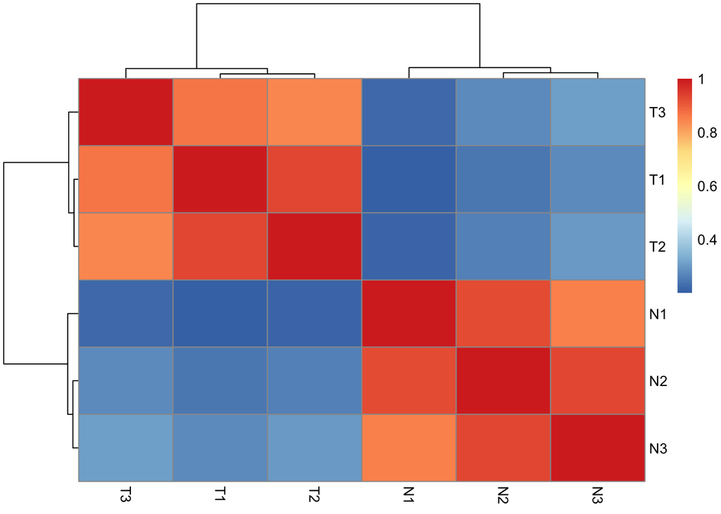

```r
# calculate pair-wise correlations of samples based on gene-level counts
gene_correlation <- cor(RSEM_counts, method="pearson")
pheatmap(gene_correlation, fontsize = 10)
```

```r
# create count matrix for isoform levels

expected_counts_list_isoforms <- lapply(RSEM_isoforms_list, function(count_df) {
  return(count_df$expected_count)
})
RSEM_counts_isoforms <- do.call(cbind, expected_counts_list_isoforms)
RSEM_counts_isoforms = cbind(RSEM_N1_isoforms$gene_id, RSEM_counts_isoforms)
colnames(RSEM_counts_isoforms) <- c("gene_id", "N1", "N2", "N3", "T1", "T2", "T3")
rownames(RSEM_counts_isoforms) = RSEM_N1_isoforms$transcript_id
head(RSEM_counts_isoforms)
```

```
                gene_id           N1       N2       N3       T1       T2
ENST00000367770 "ENSG00000000457" "56"     "0"      "0"      "0"      "0"
ENST00000367771 "ENSG00000000457" "206.03" "388.02" "403.36" "342.94" "370.43"
ENST00000367772 "ENSG00000000457" "68.12"  "132.35" "135.06" "131.35" "101.1"
ENST00000423670 "ENSG00000000457" "0"      "7.08"   "0"      "0"      "0"
ENST00000470238 "ENSG00000000457" "22.85"  "10.22"  "10.81"  "5.27"   "24.52"
ENST00000286031 "ENSG00000000460" "0"      "0"      "10.37"  "0"      "9.15"
                T3
ENST00000367770 "0"
ENST00000367771 "349"
ENST00000367772 "67.88"
ENST00000423670 "0"
ENST00000470238 "0"
ENST00000286031 "9.25"
```

For both, gene and isoform levels, it is visible that the correlation within the condition is much higher than to samples of the other condition.

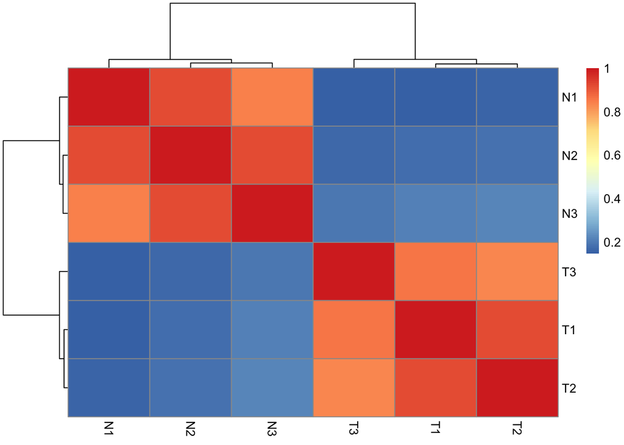

```r
# calculate pair-wise correlations of samples based on isoform counts
RSEM_counts_isoforms = RSEM_counts_isoforms %>% as.data.frame() %>% mutate(across(2:7, ~as.numeric(.)))

isoform_correlation <- cor(RSEM_counts_isoforms[,2:7], method="pearson")
pheatmap(isoform_correlation, fontsize = 10)
```

Calculate correlation of summed up isoform counts per gene and gene counts

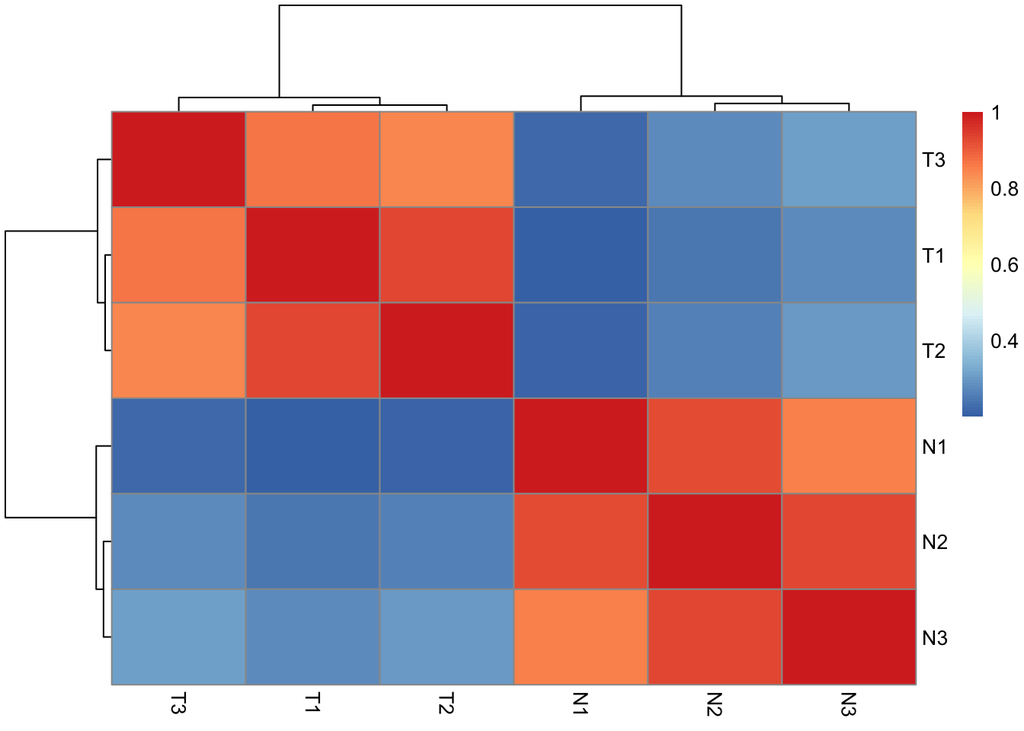

```r
RSEM_counts_summed_isoforms <- RSEM_counts_isoforms %>%
  group_by(gene_id) %>%
  summarise(across(N1:T3, sum)) %>%
  mutate(across(2:7, ~as.numeric(.))) %>%
  as.data.frame()

rownames(RSEM_counts_summed_isoforms) = RSEM_counts_summed_isoforms$gene_id
RSEM_counts_summed_isoforms$gene_id = NULL

RSEM_counts_summed_isoforms = RSEM_counts_summed_isoforms[rownames(RSEM_counts),]

isoform_gene_cor = cor(RSEM_counts_summed_isoforms, RSEM_counts, method = "pearson")
pheatmap(isoform_gene_cor, fontsize = 10)
```

Summed up isoform level results have same counts as gene levels. There are only small differences in the first decimal place in a few genes. This gives a correlation of 1 comparing summed isoform and gene counts.